Home

# Exploratory Data Analysis and Model Prediction

# Main Question for us: How does the spread and lethality of Covid-19 vary among states of different demographics, and what factors can we attribute to this? How can we use data of current Covid-19 cases and deaths to accurately predict the future?

**This is a long notebook, so just to make it a bit easier here's a quick summary: We start with cleaning the data, then move onto finding correlations between cases and deaths, then afterwards we analyze states death ratios (deaths/cases) and try to find explanations for why certain states had such large spikes in their death ratios, such as Washington towards the beginning of the pandemic. After this, we move onto predictive models. We start with a couple models that didn't work for predictions (linear regresstion), then move onto the ARIMA model, which the combines autoregressive model and integrated moving average, for forecasting our data.**

```python
#import the packages that we need
import pandas as pd
import numpy as np
import matplotlib.pyplot as plt
import matplotlib.image as mpimg
import warnings
warnings.filterwarnings("ignore")
import seaborn as sns
from datetime import datetime
%matplotlib inline
```

```python
#read the csv files containing our data of cornavirus cases and deaths in the United States
confirmedUS_raw = pd.read_csv('time_series_covid19_confirmed_US.csv')
deathsUS_raw = pd.read_csv('time_series_covid19_deaths_US.csv')
```

# Cleaning up the Data for Confirmed Cases in US:

We start by dropping columns that are not necessary to what we are trying to learn. We also transform the Data Frames so that we can later use the Data Frames for plotting and prediction.

```python
confirmedUS_raw.columns

#delete unnecessary items
items_to_delete = ['Lat', 'Long_', 'Combined_Key', 'UID', 'iso2', 'iso3', 'code3', 'FIPS', 'Country_Region', 'Admin2']
confirmedUS_raw = confirmedUS_raw.drop(columns=items_to_delete, axis=0)
confirmedUS

#format the data frame to use for data
confirmedUS = confirmedUS_raw.groupby("Province_State",sort=True).sum()
confirmedUS = confirmedUS.drop(["Diamond Princess"])
confirmedUS = confirmedUS.T

#create column "Total" which sums up the total confirmed cases for that day in the United States
confirmedUS["Total"] = confirmedUS_raw.iloc[1:].sum(axis=0)
confirmedUS
```

| Province_State | Alabama | Alaska | American Samoa | Arizona | Arkansas | California | Colorado | Connecticut | Delaware | District of Columbia | ... | Texas | Utah | Vermont | Virgin Islands | Virginia | Washington | West Virginia | Wisconsin | Wyoming | Total |
| --- | --- | --- | --- | --- | --- | --- | --- | --- | --- | --- | --- | --- | --- | --- | --- | --- | --- | --- | --- | --- | --- |
| 1/22/20 | 0 | 0 | 0 | 0 | 0 | 0 | 0 | 0 | 0 | 0 | ... | 0 | 0 | 0 | 0 | 0 | 1 | 0 | 0 | 0 | 1 |
| 1/23/20 | 0 | 0 | 0 | 0 | 0 | 0 | 0 | 0 | 0 | 0 | ... | 0 | 0 | 0 | 0 | 0 | 1 | 0 | 0 | 0 | 1 |
| 1/24/20 | 0 | 0 | 0 | 0 | 0 | 0 | 0 | 0 | 0 | 0 | ... | 0 | 0 | 0 | 0 | 0 | 1 | 0 | 0 | 0 | 2 |
| 1/25/20 | 0 | 0 | 0 | 0 | 0 | 0 | 0 | 0 | 0 | 0 | ... | 0 | 0 | 0 | 0 | 0 | 1 | 0 | 0 | 0 | 2 |
| 1/26/20 | 0 | 0 | 0 | 1 | 0 | 2 | 0 | 0 | 0 | 0 | ... | 0 | 0 | 0 | 0 | 0 | 1 | 0 | 0 | 0 | 5 |
| ... | ... | ... | ... | ... | ... | ... | ... | ... | ... | ... | ... | ... | ... | ... | ... | ... | ... | ... | ... | ... | ... |
| 5/22/20 | 13670 | 403 | 0 | 15624 | 5612 | 90252 | 23487 | 39640 | 8529 | 7893 | ... | 53539 | 8057 | 952 | 69 | 34950 | 19265 | 1705 | 14396 | 803 | 1600937 |
| 5/23/20 | 14117 | 407 | 0 | 16053 | 5775 | 92539 | 23964 | 40022 | 8529 | 7966 | ... | 54776 | 8260 | 954 | 69 | 35749 | 19265 | 1705 | 14877 | 813 | 1622612 |
| 5/24/20 | 14478 | 407 | 0 | 16377 | 5922 | 94020 | 24174 | 40468 | 8809 | 8110 | ... | 55861 | 8392 | 956 | 69 | 36244 | 19828 | 1759 | 15277 | 838 | 1643246 |
| 5/25/20 | 14986 | 408 | 0 | 16575 | 6029 | 96400 | 24256 | 40873 | 8965 | 8225 | ... | 56409 | 8521 | 962 | 69 | 37727 | 20065 | 1774 | 15584 | 843 | 1662302 |
| 5/26/20 | 15650 | 410 | 0 | 16864 | 6180 | 99387 | 24552 | 41303 | 9066 | 8334 | ... | 57230 | 8620 | 967 | 69 | 39342 | 20181 | 1774 | 15863 | 850 | 1680913 |

126 rows × 58 columns

# Cleaned Confirmed US Data Ready to Use:

```python
confirmedUS.index = confirmedUS.index.set_names('Date')
confirmedUS = confirmedUS.reset_index()
#change the "Date" column from a string to a time stamp
confirmedUS["Date"] = pd.to_datetime(confirmedUS["Date"],infer_datetime_format=True)
confirmedUS.head()
```

| Province_State | Date | Alabama | Alaska | American Samoa | Arizona | Arkansas | California | Colorado | Connecticut | Delaware | ... | Texas | Utah | Vermont | Virgin Islands | Virginia | Washington | West Virginia | Wisconsin | Wyoming | Total |
| --- | --- | --- | --- | --- | --- | --- | --- | --- | --- | --- | --- | --- | --- | --- | --- | --- | --- | --- | --- | --- | --- |
| 0 | 2020-01-22 | 0 | 0 | 0 | 0 | 0 | 0 | 0 | 0 | 0 | ... | 0 | 0 | 0 | 0 | 0 | 1 | 0 | 0 | 0 | 1 |
| 1 | 2020-01-23 | 0 | 0 | 0 | 0 | 0 | 0 | 0 | 0 | 0 | ... | 0 | 0 | 0 | 0 | 0 | 1 | 0 | 0 | 0 | 1 |
| 2 | 2020-01-24 | 0 | 0 | 0 | 0 | 0 | 0 | 0 | 0 | 0 | ... | 0 | 0 | 0 | 0 | 0 | 1 | 0 | 0 | 0 | 2 |
| 3 | 2020-01-25 | 0 | 0 | 0 | 0 | 0 | 0 | 0 | 0 | 0 | ... | 0 | 0 | 0 | 0 | 0 | 1 | 0 | 0 | 0 | 2 |
| 4 | 2020-01-26 | 0 | 0 | 0 | 1 | 0 | 2 | 0 | 0 | 0 | ... | 0 | 0 | 0 | 0 | 0 | 1 | 0 | 0 | 0 | 5 |

5 rows × 59 columns

# Cleaning up the Data for Confirmed Deaths in US:

```python
#delete unnecessary items
columns_to_delete = ['UID', 'iso2', 'iso3', 'code3', 'Admin2', 'Country_Region', "Lat", 'Long_', 'FIPS', 'Combined_Key']
deathsUS_raw = deathsUS_raw.drop(columns=columns_to_delete, axis=0)
deathsUS = deathsUS_raw.drop(columns=['Population'], axis=0)

#format data frame to use for plots
deathsUS = deathsUS.groupby("Province_State",sort=True).sum()
deathsUS = deathsUS.drop(["Diamond Princess"])
deathsUS = deathsUS.T

#add column "Total" that is a sum of the total deaths the United States experienced on a given day
deathsUS["Total"] = deathsUS_raw.iloc[1:].sum(axis=0)
deathsUS
```

| Province_State | Alabama | Alaska | American Samoa | Arizona | Arkansas | California | Colorado | Connecticut | Delaware | District of Columbia | ... | Texas | Utah | Vermont | Virgin Islands | Virginia | Washington | West Virginia | Wisconsin | Wyoming | Total |
| --- | --- | --- | --- | --- | --- | --- | --- | --- | --- | --- | --- | --- | --- | --- | --- | --- | --- | --- | --- | --- | --- |
| 1/22/20 | 0 | 0 | 0 | 0 | 0 | 0 | 0 | 0 | 0 | 0 | ... | 0 | 0 | 0 | 0 | 0 | 0 | 0 | 0 | 0 | 0 |
| 1/23/20 | 0 | 0 | 0 | 0 | 0 | 0 | 0 | 0 | 0 | 0 | ... | 0 | 0 | 0 | 0 | 0 | 0 | 0 | 0 | 0 | 0 |
| 1/24/20 | 0 | 0 | 0 | 0 | 0 | 0 | 0 | 0 | 0 | 0 | ... | 0 | 0 | 0 | 0 | 0 | 0 | 0 | 0 | 0 | 0 |
| 1/25/20 | 0 | 0 | 0 | 0 | 0 | 0 | 0 | 0 | 0 | 0 | ... | 0 | 0 | 0 | 0 | 0 | 0 | 0 | 0 | 0 | 0 |
| 1/26/20 | 0 | 0 | 0 | 0 | 0 | 0 | 0 | 0 | 0 | 0 | ... | 0 | 0 | 0 | 0 | 0 | 0 | 0 | 0 | 0 | 0 |
| ... | ... | ... | ... | ... | ... | ... | ... | ... | ... | ... | ... | ... | ... | ... | ... | ... | ... | ... | ... | ... | ... |
| 5/22/20 | 541 | 10 | 0 | 775 | 113 | 3666 | 1324 | 3637 | 322 | 418 | ... | 1470 | 93 | 54 | 6 | 1136 | 1050 | 72 | 496 | 12 | 95979 |
| 5/23/20 | 549 | 10 | 0 | 801 | 115 | 3738 | 1327 | 3675 | 322 | 427 | ... | 1478 | 97 | 54 | 6 | 1159 | 1050 | 72 | 507 | 12 | 97087 |
| 5/24/20 | 551 | 10 | 0 | 801 | 116 | 3754 | 1332 | 3693 | 326 | 432 | ... | 1528 | 97 | 54 | 6 | 1171 | 1061 | 72 | 510 | 12 | 97720 |
| 5/25/20 | 566 | 10 | 0 | 807 | 117 | 3769 | 1333 | 3742 | 332 | 440 | ... | 1533 | 98 | 54 | 6 | 1208 | 1070 | 72 | 514 | 12 | 98220 |
| 5/26/20 | 580 | 10 | 0 | 810 | 119 | 3819 | 1352 | 3769 | 335 | 440 | ... | 1546 | 101 | 54 | 6 | 1236 | 1078 | 72 | 517 | 13 | 98913 |

126 rows × 58 columns

# Cleaned Deaths US Data Ready to Use:

```python
deathsUS.index = deathsUS.index.set_names('Date')
deathsUS = deathsUS.reset_index()
#change the "Date" column data type from string to time stamp
deathsUS["Date"] = pd.to_datetime(deathsUS["Date"],infer_datetime_format=True)
deathsUS
```

| Province_State | Date | Alabama | Alaska | American Samoa | Arizona | Arkansas | California | Colorado | Connecticut | Delaware | ... | Texas | Utah | Vermont | Virgin Islands | Virginia | Washington | West Virginia | Wisconsin | Wyoming | Total |
| --- | --- | --- | --- | --- | --- | --- | --- | --- | --- | --- | --- | --- | --- | --- | --- | --- | --- | --- | --- | --- | --- |
| 0 | 2020-01-22 | 0 | 0 | 0 | 0 | 0 | 0 | 0 | 0 | 0 | ... | 0 | 0 | 0 | 0 | 0 | 0 | 0 | 0 | 0 | 0 |
| 1 | 2020-01-23 | 0 | 0 | 0 | 0 | 0 | 0 | 0 | 0 | 0 | ... | 0 | 0 | 0 | 0 | 0 | 0 | 0 | 0 | 0 | 0 |
| 2 | 2020-01-24 | 0 | 0 | 0 | 0 | 0 | 0 | 0 | 0 | 0 | ... | 0 | 0 | 0 | 0 | 0 | 0 | 0 | 0 | 0 | 0 |
| 3 | 2020-01-25 | 0 | 0 | 0 | 0 | 0 | 0 | 0 | 0 | 0 | ... | 0 | 0 | 0 | 0 | 0 | 0 | 0 | 0 | 0 | 0 |
| 4 | 2020-01-26 | 0 | 0 | 0 | 0 | 0 | 0 | 0 | 0 | 0 | ... | 0 | 0 | 0 | 0 | 0 | 0 | 0 | 0 | 0 | 0 |
| ... | ... | ... | ... | ... | ... | ... | ... | ... | ... | ... | ... | ... | ... | ... | ... | ... | ... | ... | ... | ... | ... |
| 121 | 2020-05-22 | 541 | 10 | 0 | 775 | 113 | 3666 | 1324 | 3637 | 322 | ... | 1470 | 93 | 54 | 6 | 1136 | 1050 | 72 | 496 | 12 | 95979 |
| 122 | 2020-05-23 | 549 | 10 | 0 | 801 | 115 | 3738 | 1327 | 3675 | 322 | ... | 1478 | 97 | 54 | 6 | 1159 | 1050 | 72 | 507 | 12 | 97087 |
| 123 | 2020-05-24 | 551 | 10 | 0 | 801 | 116 | 3754 | 1332 | 3693 | 326 | ... | 1528 | 97 | 54 | 6 | 1171 | 1061 | 72 | 510 | 12 | 97720 |
| 124 | 2020-05-25 | 566 | 10 | 0 | 807 | 117 | 3769 | 1333 | 3742 | 332 | ... | 1533 | 98 | 54 | 6 | 1208 | 1070 | 72 | 514 | 12 | 98220 |
| 125 | 2020-05-26 | 580 | 10 | 0 | 810 | 119 | 3819 | 1352 | 3769 | 335 | ... | 1546 | 101 | 54 | 6 | 1236 | 1078 | 72 | 517 | 13 | 98913 |

126 rows × 59 columns

## Deaths per day vs. cases per day

Here we create a new Data Frame to hold the information for the total deaths and cases each day in the united states. This way we can make overall ratios of this information.

```python
#Create new Data Frame to have Deaths and Cases in same frame
d = {"Date": confirmedUS.Date, "Death_per_day":deathsUS.Total, "Cases_per_day":confirmedUS.Total}
newcompare = pd.DataFrame(data = d)
newcompare.fillna(0)
newcompare.tail()
```

|  | Date | Death_per_day | Cases_per_day |
| --- | --- | --- | --- |
| 121 | 2020-05-22 | 95979 | 1600937 |
| 122 | 2020-05-23 | 97087 | 1622612 |
| 123 | 2020-05-24 | 97720 | 1643246 |
| 124 | 2020-05-25 | 98220 | 1662302 |
| 125 | 2020-05-26 | 98913 | 1680913 |

Below plot is of the deaths per day and the cases per day of the United States as a whole

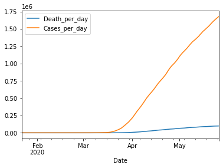

```python
columns=["Death_per_day", "Cases_per_day"]
USPlotTotals = newcompare.plot(x="Date", y=columns)
```

```python
newcompare["deaths_vs_confirmed"] = newcompare["Death_per_day"]/newcompare["Cases_per_day"]
```

Adds a new column deaths_vs_confirmed which calculates the ratio of deaths per cases per day

```python
newcompare.tail()
```

|  | Date | Death_per_day | Cases_per_day | deaths_vs_confirmed |
| --- | --- | --- | --- | --- |
| 121 | 2020-05-22 | 95979 | 1600937 | 0.0599518 |
| 122 | 2020-05-23 | 97087 | 1622612 | 0.0598338 |
| 123 | 2020-05-24 | 97720 | 1643246 | 0.0594677 |
| 124 | 2020-05-25 | 98220 | 1662302 | 0.0590867 |
| 125 | 2020-05-26 | 98913 | 1680913 | 0.0588448 |

The plot before represents the ratio of deaths per day over confirmed cases per day over the dates in the US. You see how the ratio is changing over the dates, however, it does not account for how big the population of those infected are.

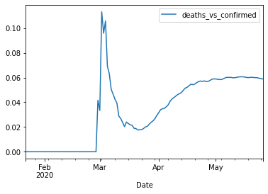

```python
USRatioPlotTotal = newcompare.plot(x="Date", y = "deaths_vs_confirmed")
```

The plot below however plots cases per day vs deaths per day. This shows that there is an increase in when the cases increase per day the deaths increase with the data.

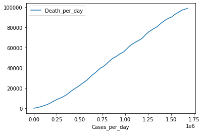

```python
Uscorrelationtotal = newcompare.plot(x="Cases_per_day", y = "Death_per_day")
```

## Deaths in the US and Population (for overall insight)

We begin to look at the population of each state in the United States so that we can later use it to make conclusions about cases and deaths of coronavirus

```python
population = pd.DataFrame({"Province_State":deathsUS_raw["Province_State"], "Population":deathsUS_raw["Population"]})
population.head()
```

|  | Province_State | Population |
| --- | --- | --- |
| 0 | American Samoa | 55641 |
| 1 | Guam | 164229 |
| 2 | Northern Mariana Islands | 55144 |
| 3 | Puerto Rico | 2933408 |
| 4 | Virgin Islands | 107268 |

```python
population = population.groupby("Province_State", sort=True).sum()
```

```python
population.head()
```

| Province_State | Population |
| --- | --- |
| Alabama | 4903185 |
| Alaska | 731545 |
| American Samoa | 55641 |
| Arizona | 7278717 |
| Arkansas | 3017804 |

# Now Let's Find the States with the Highest and Lowest Case to Death Ratio:

**Already calculated confirmed cases by state over time**:

```python
confirmedUS
```

| Province_State | Date | Alabama | Alaska | American Samoa | Arizona | Arkansas | California | Colorado | Connecticut | Delaware | ... | Texas | Utah | Vermont | Virgin Islands | Virginia | Washington | West Virginia | Wisconsin | Wyoming | Total |
| --- | --- | --- | --- | --- | --- | --- | --- | --- | --- | --- | --- | --- | --- | --- | --- | --- | --- | --- | --- | --- | --- |
| 0 | 2020-01-22 | 0 | 0 | 0 | 0 | 0 | 0 | 0 | 0 | 0 | ... | 0 | 0 | 0 | 0 | 0 | 1 | 0 | 0 | 0 | 1 |
| 1 | 2020-01-23 | 0 | 0 | 0 | 0 | 0 | 0 | 0 | 0 | 0 | ... | 0 | 0 | 0 | 0 | 0 | 1 | 0 | 0 | 0 | 1 |
| 2 | 2020-01-24 | 0 | 0 | 0 | 0 | 0 | 0 | 0 | 0 | 0 | ... | 0 | 0 | 0 | 0 | 0 | 1 | 0 | 0 | 0 | 2 |
| 3 | 2020-01-25 | 0 | 0 | 0 | 0 | 0 | 0 | 0 | 0 | 0 | ... | 0 | 0 | 0 | 0 | 0 | 1 | 0 | 0 | 0 | 2 |
| 4 | 2020-01-26 | 0 | 0 | 0 | 1 | 0 | 2 | 0 | 0 | 0 | ... | 0 | 0 | 0 | 0 | 0 | 1 | 0 | 0 | 0 | 5 |
| ... | ... | ... | ... | ... | ... | ... | ... | ... | ... | ... | ... | ... | ... | ... | ... | ... | ... | ... | ... | ... | ... |
| 121 | 2020-05-22 | 13670 | 403 | 0 | 15624 | 5612 | 90252 | 23487 | 39640 | 8529 | ... | 53539 | 8057 | 952 | 69 | 34950 | 19265 | 1705 | 14396 | 803 | 1600937 |
| 122 | 2020-05-23 | 14117 | 407 | 0 | 16053 | 5775 | 92539 | 23964 | 40022 | 8529 | ... | 54776 | 8260 | 954 | 69 | 35749 | 19265 | 1705 | 14877 | 813 | 1622612 |
| 123 | 2020-05-24 | 14478 | 407 | 0 | 16377 | 5922 | 94020 | 24174 | 40468 | 8809 | ... | 55861 | 8392 | 956 | 69 | 36244 | 19828 | 1759 | 15277 | 838 | 1643246 |
| 124 | 2020-05-25 | 14986 | 408 | 0 | 16575 | 6029 | 96400 | 24256 | 40873 | 8965 | ... | 56409 | 8521 | 962 | 69 | 37727 | 20065 | 1774 | 15584 | 843 | 1662302 |
| 125 | 2020-05-26 | 15650 | 410 | 0 | 16864 | 6180 | 99387 | 24552 | 41303 | 9066 | ... | 57230 | 8620 | 967 | 69 | 39342 | 20181 | 1774 | 15863 | 850 | 1680913 |

126 rows × 59 columns

**Already calculated deaths by state over time**:

```python
deathsUS
```

| Province_State | Date | Alabama | Alaska | American Samoa | Arizona | Arkansas | California | Colorado | Connecticut | Delaware | ... | Texas | Utah | Vermont | Virgin Islands | Virginia | Washington | West Virginia | Wisconsin | Wyoming | Total |
| --- | --- | --- | --- | --- | --- | --- | --- | --- | --- | --- | --- | --- | --- | --- | --- | --- | --- | --- | --- | --- | --- |
| 0 | 2020-01-22 | 0 | 0 | 0 | 0 | 0 | 0 | 0 | 0 | 0 | ... | 0 | 0 | 0 | 0 | 0 | 0 | 0 | 0 | 0 | 0 |
| 1 | 2020-01-23 | 0 | 0 | 0 | 0 | 0 | 0 | 0 | 0 | 0 | ... | 0 | 0 | 0 | 0 | 0 | 0 | 0 | 0 | 0 | 0 |
| 2 | 2020-01-24 | 0 | 0 | 0 | 0 | 0 | 0 | 0 | 0 | 0 | ... | 0 | 0 | 0 | 0 | 0 | 0 | 0 | 0 | 0 | 0 |
| 3 | 2020-01-25 | 0 | 0 | 0 | 0 | 0 | 0 | 0 | 0 | 0 | ... | 0 | 0 | 0 | 0 | 0 | 0 | 0 | 0 | 0 | 0 |
| 4 | 2020-01-26 | 0 | 0 | 0 | 0 | 0 | 0 | 0 | 0 | 0 | ... | 0 | 0 | 0 | 0 | 0 | 0 | 0 | 0 | 0 | 0 |
| ... | ... | ... | ... | ... | ... | ... | ... | ... | ... | ... | ... | ... | ... | ... | ... | ... | ... | ... | ... | ... | ... |
| 121 | 2020-05-22 | 541 | 10 | 0 | 775 | 113 | 3666 | 1324 | 3637 | 322 | ... | 1470 | 93 | 54 | 6 | 1136 | 1050 | 72 | 496 | 12 | 95979 |
| 122 | 2020-05-23 | 549 | 10 | 0 | 801 | 115 | 3738 | 1327 | 3675 | 322 | ... | 1478 | 97 | 54 | 6 | 1159 | 1050 | 72 | 507 | 12 | 97087 |
| 123 | 2020-05-24 | 551 | 10 | 0 | 801 | 116 | 3754 | 1332 | 3693 | 326 | ... | 1528 | 97 | 54 | 6 | 1171 | 1061 | 72 | 510 | 12 | 97720 |
| 124 | 2020-05-25 | 566 | 10 | 0 | 807 | 117 | 3769 | 1333 | 3742 | 332 | ... | 1533 | 98 | 54 | 6 | 1208 | 1070 | 72 | 514 | 12 | 98220 |
| 125 | 2020-05-26 | 580 | 10 | 0 | 810 | 119 | 3819 | 1352 | 3769 | 335 | ... | 1546 | 101 | 54 | 6 | 1236 | 1078 | 72 | 517 | 13 | 98913 |

126 rows × 59 columns

**Case to death ratio was also shown a bit earlier, but we need to do for every state:**

```python
#makes an empty DataFrame with same formatting as confirmed cases in US
caseToDeathRatioUS = pd.DataFrame().reindex_like(confirmedUS)
caseToDeathRatioUS.Date = confirmedUS.Date
#want to find death rate for each state
caseToDeathRatioUS = deathsUS.loc[:, "Alabama":].div(confirmedUS.loc[:, "Alabama":], axis=0)
caseToDeathRatioUS.insert(0, "Date", confirmedUS.loc[:, "Date"])
#now just need to make date into date-time values and fill NaN with 0 so we can graph:
caseToDeathRatioUS["Date"] = pd.to_datetime(caseToDeathRatioUS["Date"])
caseToDeathRatioUS = caseToDeathRatioUS.fillna(0)
caseToDeathRatioUS
```

| Province_State | Date | Alabama | Alaska | American Samoa | Arizona | Arkansas | California | Colorado | Connecticut | Delaware | ... | Texas | Utah | Vermont | Virgin Islands | Virginia | Washington | West Virginia | Wisconsin | Wyoming | Total |
| --- | --- | --- | --- | --- | --- | --- | --- | --- | --- | --- | --- | --- | --- | --- | --- | --- | --- | --- | --- | --- | --- |
| 0 | 2020-01-22 | 0.000000 | 0.000000 | 0.0 | 0.000000 | 0.000000 | 0.000000 | 0.000000 | 0.000000 | 0.000000 | ... | 0.000000 | 0.000000 | 0.000000 | 0.000000 | 0.000000 | 0.000000 | 0.000000 | 0.000000 | 0.000000 | 0.000000 |
| 1 | 2020-01-23 | 0.000000 | 0.000000 | 0.0 | 0.000000 | 0.000000 | 0.000000 | 0.000000 | 0.000000 | 0.000000 | ... | 0.000000 | 0.000000 | 0.000000 | 0.000000 | 0.000000 | 0.000000 | 0.000000 | 0.000000 | 0.000000 | 0.000000 |
| 2 | 2020-01-24 | 0.000000 | 0.000000 | 0.0 | 0.000000 | 0.000000 | 0.000000 | 0.000000 | 0.000000 | 0.000000 | ... | 0.000000 | 0.000000 | 0.000000 | 0.000000 | 0.000000 | 0.000000 | 0.000000 | 0.000000 | 0.000000 | 0.000000 |
| 3 | 2020-01-25 | 0.000000 | 0.000000 | 0.0 | 0.000000 | 0.000000 | 0.000000 | 0.000000 | 0.000000 | 0.000000 | ... | 0.000000 | 0.000000 | 0.000000 | 0.000000 | 0.000000 | 0.000000 | 0.000000 | 0.000000 | 0.000000 | 0.000000 |
| 4 | 2020-01-26 | 0.000000 | 0.000000 | 0.0 | 0.000000 | 0.000000 | 0.000000 | 0.000000 | 0.000000 | 0.000000 | ... | 0.000000 | 0.000000 | 0.000000 | 0.000000 | 0.000000 | 0.000000 | 0.000000 | 0.000000 | 0.000000 | 0.000000 |
| ... | ... | ... | ... | ... | ... | ... | ... | ... | ... | ... | ... | ... | ... | ... | ... | ... | ... | ... | ... | ... | ... |
| 121 | 2020-05-22 | 0.039576 | 0.024814 | 0.0 | 0.049603 | 0.020135 | 0.040620 | 0.056372 | 0.091751 | 0.037754 | ... | 0.027457 | 0.011543 | 0.056723 | 0.086957 | 0.032504 | 0.054503 | 0.042229 | 0.034454 | 0.014944 | 0.059952 |
| 122 | 2020-05-23 | 0.038889 | 0.024570 | 0.0 | 0.049897 | 0.019913 | 0.040394 | 0.055375 | 0.091824 | 0.037754 | ... | 0.026983 | 0.011743 | 0.056604 | 0.086957 | 0.032420 | 0.054503 | 0.042229 | 0.034079 | 0.014760 | 0.059834 |
| 123 | 2020-05-24 | 0.038058 | 0.024570 | 0.0 | 0.048910 | 0.019588 | 0.039928 | 0.055101 | 0.091257 | 0.037008 | ... | 0.027354 | 0.011559 | 0.056485 | 0.086957 | 0.032309 | 0.053510 | 0.040932 | 0.033384 | 0.014320 | 0.059468 |
| 124 | 2020-05-25 | 0.037769 | 0.024510 | 0.0 | 0.048688 | 0.019406 | 0.039098 | 0.054955 | 0.091552 | 0.037033 | ... | 0.027177 | 0.011501 | 0.056133 | 0.086957 | 0.032020 | 0.053327 | 0.040586 | 0.032983 | 0.014235 | 0.059087 |
| 125 | 2020-05-26 | 0.037061 | 0.024390 | 0.0 | 0.048031 | 0.019256 | 0.038426 | 0.055067 | 0.091252 | 0.036951 | ... | 0.027014 | 0.011717 | 0.055843 | 0.086957 | 0.031417 | 0.053417 | 0.040586 | 0.032592 | 0.015294 | 0.058845 |

126 rows × 59 columns

```python
caseToDeathRatioUS.dtypes
```

```
Province_State
Date                        datetime64[ns]
Alabama                            float64
Alaska                             float64
American Samoa                     float64
Arizona                            float64
Arkansas                           float64
California                         float64
Colorado                           float64
Connecticut                        float64
Delaware                           float64
District of Columbia               float64
Florida                            float64
Georgia                            float64
Grand Princess                     float64
Guam                               float64
Hawaii                             float64
Idaho                              float64
Illinois                           float64
Indiana                            float64
Iowa                               float64
Kansas                             float64
Kentucky                           float64
Louisiana                          float64
Maine                              float64
Maryland                           float64
Massachusetts                      float64
Michigan                           float64
Minnesota                          float64
Mississippi                        float64
Missouri                           float64
Montana                            float64
Nebraska                           float64
Nevada                             float64
New Hampshire                      float64
New Jersey                         float64
New Mexico                         float64
New York                           float64
North Carolina                     float64
North Dakota                       float64
Northern Mariana Islands           float64
Ohio                               float64
Oklahoma                           float64
Oregon                             float64
Pennsylvania                       float64
Puerto Rico                        float64
Rhode Island                       float64
South Carolina                     float64
South Dakota                       float64
Tennessee                          float64
Texas                              float64
Utah                               float64
Vermont                            float64
Virgin Islands                     float64
Virginia                           float64
Washington                         float64
West Virginia                      float64
Wisconsin                          float64
Wyoming                            float64
Total                              float64
dtype: object
```

## As can be seen in the following graph, the death rates in each state have largely leveled off in a range of 0.01 - 0.10. More importantly, it can be seen that there are several large spikes in death rates in certain states, such as the large red spike at the beginning.

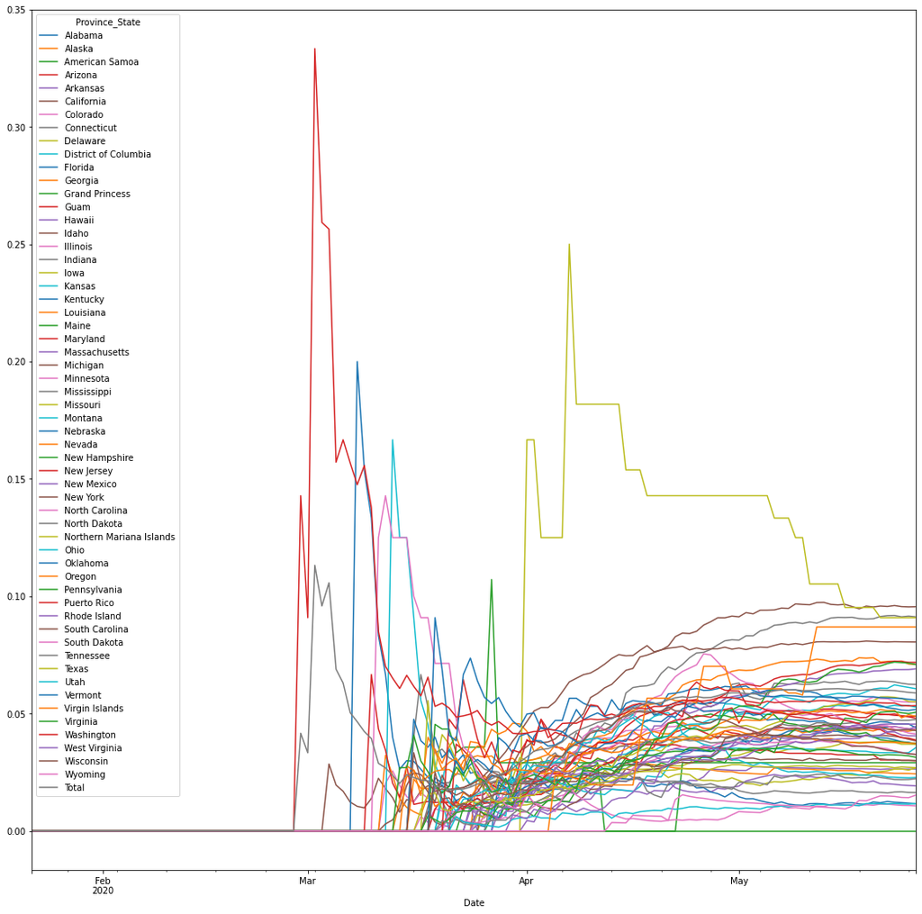

```python
#visual representation:
caseToDeathRatioUS.plot(x="Date", figsize=(18,18))
```

**Finding the 5 states with largest spikes:**

```python
states = ['Alabama', 'Alaska', 'American Samoa', 'Arizona', 'Arkansas',
       'California', 'Colorado', 'Connecticut', 'Delaware',
       'District of Columbia', 'Florida', 'Georgia', 'Guam',
       'Hawaii', 'Idaho', 'Illinois', 'Indiana', 'Iowa', 'Kansas', 'Kentucky',
       'Louisiana', 'Maine', 'Maryland', 'Massachusetts', 'Michigan',
       'Minnesota', 'Mississippi', 'Missouri', 'Montana', 'Nebraska', 'Nevada',
       'New Hampshire', 'New Jersey', 'New Mexico', 'New York',
       'North Carolina', 'North Dakota', 'Northern Mariana Islands', 'Ohio',
       'Oklahoma', 'Oregon', 'Pennsylvania', 'Puerto Rico', 'Rhode Island',
       'South Carolina', 'South Dakota', 'Tennessee', 'Texas', 'Utah',
       'Vermont', 'Virgin Islands', 'Virginia', 'Washington', 'West Virginia',
       'Wisconsin', 'Wyoming', 'Total']
caseToDeathRatioUS.sort_values(by=states, ascending=False)

#find max spike for each state
maxSpikes = caseToDeathRatioUS.max().to_frame(name="Maximum") #can add .T for the transposed array
```

```python
maxSpikes
```

| Province_State | Maximum |
| --- | --- |
| Date | 2020-05-26 00:00:00 |
| Alabama | 0.0426088 |
| Alaska | 0.0324324 |
| American Samoa | 0 |
| Arizona | 0.050114 |
| Arkansas | 0.024093 |
| California | 0.0409696 |
| Colorado | 0.0569812 |
| Connecticut | 0.0918245 |
| Delaware | 0.0378959 |
| District of Columbia | 0.0539202 |
| Florida | 0.2 |
| Georgia | 0.0436515 |
| Grand Princess | 0.107143 |
| Guam | 0.047619 |
| Hawaii | 0.0274194 |
| Idaho | 0.0312655 |
| Illinois | 0.0456994 |
| Indiana | 0.0666667 |
| Iowa | 0.0294469 |
| Kansas | 0.166667 |
| Kentucky | 0.0565709 |
| Louisiana | 0.0738475 |
| Maine | 0.0498534 |
| Maryland | 0.0524331 |
| Massachusetts | 0.0690873 |
| Michigan | 0.0974148 |
| Minnesota | 0.0755136 |
| Mississippi | 0.047631 |
| Missouri | 0.0571984 |
| Montana | 0.0354906 |
| Nebraska | 0.0246479 |
| Nevada | 0.0517568 |
| New Hampshire | 0.0508682 |
| New Jersey | 0.0723652 |
| New Mexico | 0.0456575 |
| New York | 0.0809364 |
| North Carolina | 0.0384074 |
| North Dakota | 0.0246575 |
| Northern Mariana Islands | 0.25 |
| Ohio | 0.0622771 |
| Oklahoma | 0.0618021 |
| Oregon | 0.0415094 |
| Pennsylvania | 0.0719909 |
| Puerto Rico | 0.0645161 |
| Rhode Island | 0.0446165 |
| South Carolina | 0.0453047 |
| South Dakota | 0.142857 |
| Tennessee | 0.0225132 |
| Texas | 0.0282904 |
| Utah | 0.0117433 |
| Vermont | 0.0909091 |
| Virgin Islands | 0.0869565 |
| Virginia | 0.0408163 |
| Washington | 0.333333 |
| West Virginia | 0.045273 |
| Wisconsin | 0.0527568 |
| Wyoming | 0.0154525 |
| Total | 0.113208 |

```python
maxSpikes = maxSpikes.drop(["Date", "Northern Mariana Islands", "Total"])
```

```python
maxSpikes = maxSpikes.sort_values(by = 'Maximum', ascending = False)
```

```python
maxSpikes.head(6)
```

| Province_State | Maximum |
| --- | --- |
| Washington | 0.333333 |
| Florida | 0.2 |
| Kansas | 0.166667 |
| South Dakota | 0.142857 |
| Grand Princess | 0.107143 |
| Michigan | 0.0974148 |

**Then Afterwards, we compare and see why they had big spikes in death ratios.**

```python
maxStatesRatioUS = caseToDeathRatioUS[["Date", "Washington", "Florida", "Kansas", "South Dakota", "Michigan"]]
```

As seen in the plot below, Washington, Florida, Kansas, South Dakota and Michigan had the highest spikes in the case to death ratio in the United States. We use this data to try and find corelations.

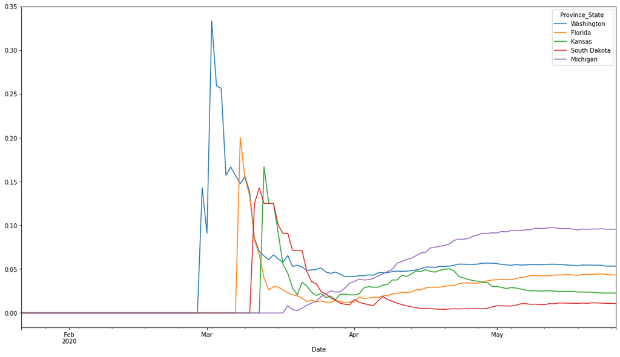

```python
maxStatesRatioUS.plot(x="Date", figsize = (18, 10))
```

As you can see in the above plot, Washington, Florida, Kansas, South Dakota and Michigan had the largest spikes in the death to case ratio of coronavirus.

Washington experienced such a large spike because of the community outbreak and the state experienced many of the cases in long-term care facilities during the time period of the spike. Washington was one of the first states to experience a community spread of COVID-19 which is why there spike in the death to case ratio is experienced early on.

Florida experienced such a large spike because of hesitation to create stay at home orders in the state. Some researches attribute this to false negatives during COVID-19 testing. People have also hesitated to seek out care or medical assistance. This rate is said to improve once medical workers got better at identifying patients with cornavirus.

Kansas has had such a large spike in the death to cases ratio because coronavirus testing rates are low per population. The state also has seen large disparities with coronavirus infecting minority groups. Kansas also has the largest racial disparities in COVID-19 death rates. 30% of the coronavirus deaths have been African Americans despite African Americans only making up 5.6% of the states popultion.

South Dakota has experienced a high spike in the death to cases ratio because of spreads in nursing homes. The community outbreak in the state is primarily experienced in these nursing homes that contain the at risk population, people with underlying health conditions and the elderly.

It is argued that Michigan has had such a large spike in death to cases ratio because of when coronavirus hit the state. Michigan doctors were still trying to develop protocalls when they experienced the surge in cases. It is also argued that the coronavirus is deadly in mainly nursing homes and in the African American communities of Michigan. African Americans make up 32% of cases and 41% of the deaths despite only making up 14% of the population of Michigan.

```python
testing=pd.read_csv("time_series_testing.csv")
testing=testing.fillna(0)
```

# Linear Regression Confirmed Cases to Help Predict Deaths:

We use the confirmed cases that day in the United States to predict the deaths that day

We need to change the data type of Date to float values to be used in linear regression

```python
newcompare["Date"] = newcompare.Date.values.astype(float)
newcompa = newcompare.copy()
```

This first regression uses the cases per day to predict the deaths per that day

```python
independent_variables = newcompa.drop(columns = ["Death_per_day", "deaths_vs_confirmed", "Date"]).columns
target = "Death_per_day"
```

```python
from sklearn.model_selection import train_test_split
```

```python
X = newcompare[independent_variables]
y = newcompare["Death_per_day"]
X_train, X_test, y_train, y_test = train_test_split(X,y,test_size=0.2)
```

```python
from sklearn.linear_model import LinearRegression
```

```python
model = LinearRegression()
```

```python
model.fit(X=X_train, y=y_train)
```

```
LinearRegression(copy_X=True, fit_intercept=True, n_jobs=None, normalize=False)
```

```python
predictions = model.predict(X_test)
```

```python
for y, y_pred in list(zip(y_test, predictions))[:5]:
    print("Real value: {:.3f} Estimated value: {:.5f}".format(y, y_pred))
```

```
Real value: 22.000 Estimated value: -1298.30731
Real value: 66369.000 Estimated value: 66596.30082
Real value: 32760.000 Estimated value: 36856.04900
Real value: 1011.000 Estimated value: 1904.79815
Real value: 17.000 Estimated value: -1309.22304
```

```python
X = X_test.reset_index().copy() # make a copy of indices and data
X["target"] = y_test.tolist()
X["prediction"] = predictions
X.head()
```

|  | index | Cases_per_day | target | prediction |
| --- | --- | --- | --- | --- |
| 0 | 47 | 519 | 22 | -1298.307311 |
| 1 | 101 | 1132539 | 66369 | 66596.300818 |
| 2 | 84 | 636674 | 32760 | 36856.049003 |
| 3 | 62 | 53925 | 1011 | 1904.798148 |
| 4 | 45 | 337 | 17 | -1309.223035 |

The plot below shows the prediction vs targetted value for the deaths per day

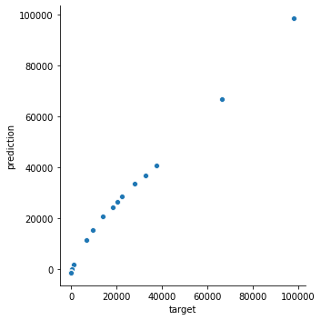

```python
sns.relplot(x="target", y="prediction", data=X, kind="scatter")
```

The plot below shows the cases per day vs the deaths that day and plots the predicted values and the actual values

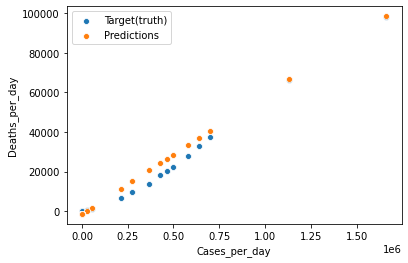

```python
sns.scatterplot(x=X["Cases_per_day"], y=X["target"], label = 'Target(truth)')
sns.scatterplot(x=X["Cases_per_day"], y=X["prediction"], label = 'Predictions')
sns.mpl.pyplot.ylabel("Deaths_per_day");
```

# Linear Regression from just dates to predict future cases:

```python
from sklearn.model_selection import train_test_split
from sklearn.linear_model import LinearRegression
```

```python
independent_variables = newcompare.drop(columns = ["Cases_per_day", "Death_per_day", "deaths_vs_confirmed"]).columns
target = "Cases_per_day"
```

```python
X = newcompare[independent_variables]
y = newcompare["Cases_per_day"]
X_train, X_test, y_train, y_test = train_test_split(X,y,test_size=0.2)
```

```python
model = LinearRegression()
model.fit(X=X_train, y=y_train)
predictions = model.predict(X_test)
```

```python
for y, y_pred in list(zip(y_test, predictions))[:5]:
    print("Real value: {:.3f} Estimated value: {:.5f}".format(y, y_pred))
```

```
Real value: 5.000 Estimated value: -341026.72800
Real value: 11.000 Estimated value: -225955.75889
Real value: 1257023.000 Estimated value: 1068592.64362
Real value: 905358.000 Estimated value: 881602.31881
Real value: 15.000 Estimated value: -24581.56294
```

```python
X = X_test.reset_index().copy() # make a copy of indices and data
X["target"] = y_test.tolist()
X["prediction"] = predictions
X["Date"] = pd.to_datetime(X["Date"])
X.head()
```

|  | index | Date | target | prediction |
| --- | --- | --- | --- | --- |
| 0 | 8 | 2020-01-30 | 5 | -3.410267e+05 |
| 1 | 16 | 2020-02-07 | 11 | -2.259558e+05 |
| 2 | 106 | 2020-05-07 | 1257023 | 1.068593e+06 |
| 3 | 93 | 2020-04-24 | 905358 | 8.816023e+05 |
| 4 | 30 | 2020-02-21 | 15 | -2.458156e+04 |

**The following plot shows the actual cases vs the prediction:**

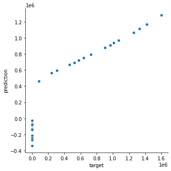

```python
sns.relplot(x="target", y="prediction", data=X, kind="scatter")
```

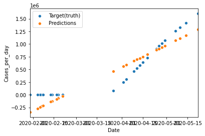

```python
sns.scatterplot(x=X["Date"], y=X["target"], label = 'Target(truth)').set(xlim=(X.Date.min(), X.Date.max()))
sns.scatterplot(x=X["Date"], y=X["prediction"], label = 'Predictions').set(xlim=(X.Date.min(), X.Date.max()))
sns.mpl.pyplot.ylabel("Cases_per_day")
```

**As can be seen by the graph above, the standard linear regression model is not a great fit for predicting cases.**

# ARIMA model to predict total future deaths in the US. We chose to predict deaths, because we see this as more significant than just total cases.

```python
from statsmodels.tsa.arima_model import ARIMA
from matplotlib.pylab import rcParams
rcParams['figure.figsize'] = 12, 6
from statsmodels.tsa.stattools import adfuller, acf, pacf
```

**Cleaning the data for forecasting and making a DataFrame for just total US deaths per day:**

```python
newcompare.head()
```

|  | Date | Death_per_day | Cases_per_day | deaths_vs_confirmed |
| --- | --- | --- | --- | --- |
| 0 | 1.579651e+18 | 0 | 1 | 0 |
| 1 | 1.579738e+18 | 0 | 1 | 0 |
| 2 | 1.579824e+18 | 0 | 2 | 0 |
| 3 | 1.579910e+18 | 0 | 2 | 0 |
| 4 | 1.579997e+18 | 0 | 5 | 0 |

```python
newcompare["Date"] = pd.to_datetime(newcompare["Date"], infer_datetime_format=True)
totalUSDeaths = newcompare.drop(columns=["Cases_per_day","deaths_vs_confirmed"])
totalUSDeaths = totalUSDeaths.set_index(["Date"])
```

**We also have to remove the earlier dates, as the trend clearly changes after around 04-01-2020, so when the number of deaths crossed the 5000 threshold**

```python
totalUSDeaths = totalUSDeaths[totalUSDeaths.Death_per_day > 5000]
totalUSDeaths.head()
```

| Date | Death_per_day |
| --- | --- |
| 2020-03-31 | 5531 |
| 2020-04-01 | 6746 |
| 2020-04-02 | 8303 |
| 2020-04-03 | 9587 |
| 2020-04-04 | 10849 |

**Graphing original data:**

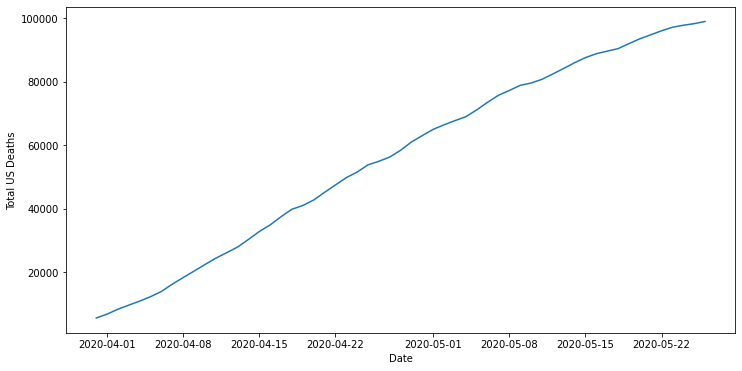

```python
plt.xlabel("Date")
plt.ylabel("Total US Deaths")
plt.plot(totalUSDeaths)
```

**ACF Plot:**

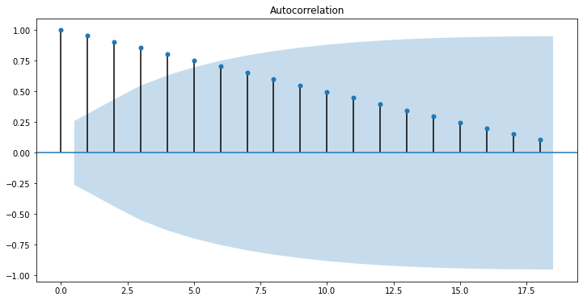

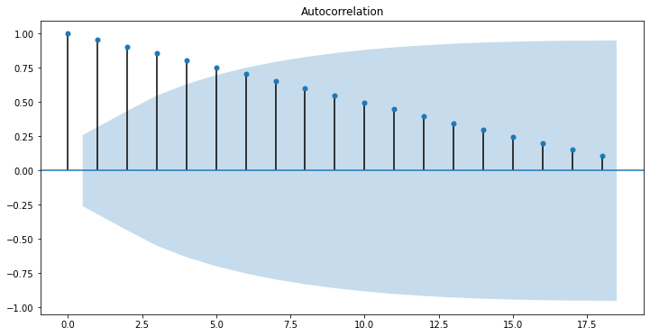

```python
from statsmodels.graphics.tsaplots import plot_acf
plot_acf(totalUSDeaths)
```

**There is clearly a downward trend here which we need to remove for the ARIMA analysis.**

```python
totalUSDeaths_diff=totalUSDeaths.diff(periods=1)
#We shifted our model 1 day to calculate the difference. In our ARIMA model this parameter is known as d

totalUSDeaths_diff.rename(columns={"Death_per_day":"Increase_Death_per_day"})
totalUSDeaths_diff=totalUSDeaths_diff[1:]
totalUSDeaths_diff.head()
```

| Date | Death_per_day |
| --- | --- |
| 2020-04-01 | 1215 |
| 2020-04-02 | 1557 |
| 2020-04-03 | 1284 |
| 2020-04-04 | 1262 |
| 2020-04-05 | 1396 |

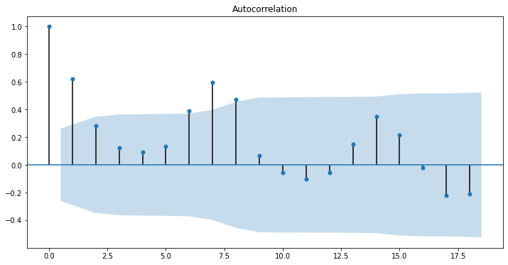

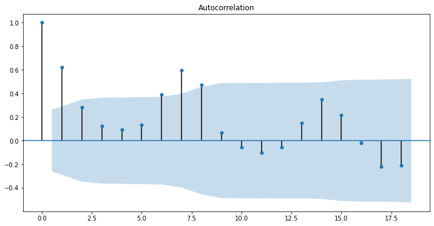

```python
plot_acf(totalUSDeaths_diff)
```

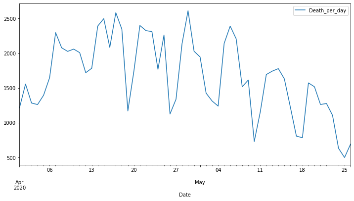

```python
totalUSDeaths_diff.plot()
```

**As can be seen, this is a much better plot, as there is not much of a trend. It's not perfect, but it's not bad given our data.**